[figure not shown]

# **MUSIC RECOMMENDATION SYSTEM**

TEAM NUMBER :7

TEAM MEMBERS:  
1) THARINI  
2) PARVATHY  
3) MADASU DEEPIKA  
4) G.HARINISRI

A recommender system is a tool that helps predicting what a user may or may not like among a list of given items. In some sense, you can view this as an alternative to content search, as recommendation engines help users discover products or content that they may not come across otherwise. For example, Facebook suggests friends and pages to users. Youtube recommends videos which users may be interested in. Amazon suggests the products which users may need. Recommendation engines engage users to services, can be seen as a revenue optimization process, and in general help maintaining interest in a service.

```python
from google.colab import drive
drive.mount('/content/drive')
```

**DOWNLOADING THE DATASET AND UNZIPPING IT**

```python
!set -e
!mkdir -p dataset
!cd dataset
!wget http://www.iro.umontreal.ca/~lisa/datasets/profiledata_06-May-2005.tar.gz
!tar xvf profiledata_06-May-2005.tar.gz
!mv profiledata_06-May-2005/* dataset/
!rm -r profiledata_06-May-2005
```

```
--2022-03-10 02:05:06--  http://www.iro.umontreal.ca/~lisa/datasets/profiledata_06-May-2005.tar.gz
Resolving www.iro.umontreal.ca (www.iro.umontreal.ca)... 132.204.26.36
Connecting to www.iro.umontreal.ca (www.iro.umontreal.ca)|132.204.26.36|:80... connected.
HTTP request sent, awaiting response... 200 OK
Length: 135880312 (130M) [application/x-gzip]
Saving to: ‘profiledata_06-May-2005.tar.gz’

profiledata_06-May- 100%[===================>] 129.58M  40.4MB/s    in 3.7s

2022-03-10 02:05:10 (35.4 MB/s) - ‘profiledata_06-May-2005.tar.gz’ saved [135880312/135880312]

profiledata_06-May-2005/
profiledata_06-May-2005/artist_data.txt
profiledata_06-May-2005/README.txt
profiledata_06-May-2005/user_artist_data.txt
profiledata_06-May-2005/artist_alias.txt
```

**USER_ARTIST_DATA.TXT**

```python
!cat dataset/user_artist_data.txt | head
```

```
1000002 1 55
1000002 1000006 33
1000002 1000007 8
1000002 1000009 144
1000002 1000010 314
1000002 1000013 8
1000002 1000014 42
1000002 1000017 69
1000002 1000024 329
1000002 1000025 1
```

**As we are going to do in pyspark and findspark environment we are installing it.**

```python
!pip install pyspark
```

```
     |████████████████████████████████| 281.4 MB 32 kB/s
     |████████████████████████████████| 198 kB 62.5 MB/s
```

```python
!pip install findspark
```

**IMPORTING THE REQUIRED LIBRARIES AND PACKAGES**

```python
import os
import sys
import re
import random
import pyspark
from pyspark import SparkContext
from pyspark.sql import SQLContext
from pyspark.sql.types import *
from pyspark.sql import Row
from pyspark.sql.functions import *

%matplotlib inline
import matplotlib.pyplot as plt
import pandas as pd
import numpy as np
from time import time
import findspark
findspark.init()
findspark.find()
import pyspark
findspark.find()
from pyspark import SparkContext, SparkConf
from pyspark.sql import SparkSession
conf = pyspark.SparkConf().setAppName('appName').setMaster('local')
sc = pyspark.SparkContext(conf=conf)
spark = SparkSession(sc)

sqlContext = SQLContext(sc)
# Base directory path
base = "/content/dataset/user_artist_data.txt"
```

## **ANALYSIS ON USER_ARTIST_DATA.TXT**

```python
userArtistDataSchema = StructType([ \
    StructField("userID", LongType(), True), \
    StructField("artistID", LongType(), True), \
    StructField("playCount", IntegerType(), True)])

userArtistDF = sqlContext.read \
    .format('com.databricks.spark.csv') \
    .options(header='false', delimiter=' ') \
    .load(base , schema = userArtistDataSchema) \
    .cache()
```

**We can cache an Dataframe to avoid computing it from the beginning everytime it is accessed.**

```python
userArtistDF.cache()
userArtistDF.show()
```

```
+-------+--------+---------+
| userID|artistID|playCount|
+-------+--------+---------+
|1000002|       1|       55|
|1000002| 1000006|       33|
|1000002| 1000007|        8|
|1000002| 1000009|      144|
|1000002| 1000010|      314|
|1000002| 1000013|        8|
|1000002| 1000014|       42|
|1000002| 1000017|       69|
|1000002| 1000024|      329|
|1000002| 1000025|        1|
|1000002| 1000028|       17|
|1000002| 1000031|       47|
|1000002| 1000033|       15|
|1000002| 1000042|        1|
|1000002| 1000045|        1|
|1000002| 1000054|        2|
|1000002| 1000055|       25|
|1000002| 1000056|        4|
|1000002| 1000059|        2|
|1000002| 1000062|       71|
+-------+--------+---------+
only showing top 20 rows
```

**How many distinct users do we have in our data?**

```python
allusers = userArtistDF.count()
print("All rows in database: ", allusers )
uniqueUsers = userArtistDF.select('userID').distinct().count()
print("Total n. of distinct users: ", uniqueUsers)
```

```
All rows in database:  24296858
Total n. of distinct users:  148111
```

**How many distinct artists do we have in our data ?**

```python
uniqueArtists = userArtistDF.select('artistID').distinct().count()
print("Total n. of artists: ", uniqueArtists)
```

```
Total n. of artists:  1631028
```

**What are the maximum and minimum values of column userID ?**

```python
MAX_VALUE = 2147483647
#showing the IDs which are invalid
userArtistDF[(userArtistDF.userID.cast("int") < 0)].show()
userArtistDF[(userArtistDF.userID.cast("int") > MAX_VALUE)].show()
# We don't see any invalid userID
userArtistDF.select("userID").describe().show()
```

```
+------+--------+---------+
|userID|artistID|playCount|
+------+--------+---------+
+------+--------+---------+

+------+--------+---------+
|userID|artistID|playCount|
+------+--------+---------+
+------+--------+---------+

+-------+------------------+
|summary|            userID|
+-------+------------------+
|  count|          24296858|
|   mean|1947573.2653533637|
| stddev| 496000.5551820078|
|    min|                90|
|    max|           2443548|
+-------+------------------+
```

**What is the maximum and minimum values of column artistID ?**

```python
max_artistID = userArtistDF.groupby().max('artistID').collect()[0].asDict()['max(artistID)']
print('Maximum value of artistID: ',max_artistID)
min_artistID = userArtistDF.groupby().min('artistID').collect()[0].asDict()['min(artistID)']
print('Minimum value of artistID: ',min_artistID)
userArtistDF.select("artistID").describe().show()
```

```
Maximum value of artistID:  10794401
Minimum value of artistID:  1
+-------+------------------+
|summary|          artistID|
+-------+------------------+
|  count|          24296858|
|   mean|1718704.0937568964|
| stddev|2539389.0924284607|
|    min|                 1|
|    max|          10794401|
+-------+------------------+
```

**How many times each user has played a song? Display 5 samples of the result.**

```python
userActivity = userArtistDF.groupBy('userID').sum('playCount').collect()
print(userActivity[0:5])
len(userActivity)
```

```
[Row(userID=1000061, sum(playCount)=244), Row(userID=1000070, sum(playCount)=20200), Row(userID=1000313, sum(playCount)=201), Row(userID=1000832, sum(playCount)=1064), Row(userID=1000905, sum(playCount)=214)]
```

```
148111
```

**Plot CDF of the number of play counts per User ID.**

We will notice that for some users, there is very little interaction with the system, which means that maybe reccommending something to them is going to be more difficult than for other users who interact more with the system. Look at outliers and reasons about their impact on the reccommender algorithm

```
[     0      1      2 ... 148108 148109 148110]
```

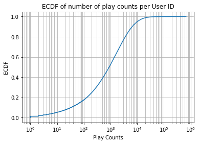

```python
pdf = pd.DataFrame(data=userActivity)
Y=np.sort( pdf[1] )
yvals=np.arange(len(Y))/float(len(Y))

print(np.arange(len(Y)))

plt.semilogx( Y, yvals )
plt.xlabel('Play Counts')
plt.ylabel('ECDF')
plt.grid(True,which="both",ls="-")
plt.title('ECDF of number of play counts per User ID')
plt.show()
```

**Statistical measurements of userAcitvity**

```python
print ('Total =', Y.sum())
print ('Mean =', Y.mean())
print ('Min =', Y.min())
print ('Max =', Y.max())
```

```
Total = 371638969
Mean = 2509.1922206993404
Min = 1
Max = 674412
```

```python
#important percentiles (25%, median, 75%, tails such as >90%)
print('Percentile 25% :' + str(np.percentile(Y,25)))
print('Percentile 50% :' + str(np.percentile(Y,50)))
print('Percentile 75% :' + str(np.percentile(Y,75)))
print('Percentile 90% :' + str(np.percentile(Y,90)))
print('Percentile 95% :' + str(np.percentile(Y,95)))
print('Percentile 99% :' + str(np.percentile(Y,99)))
```

```
Percentile 25% :204.0
Percentile 50% :892.0
Percentile 75% :2800.0
Percentile 90% :6484.0
Percentile 95% :10120.0
Percentile 99% :21569.199999999953
```

```python
#percentile has playCount less than 10
print('The percentage of user playing less than 10 times P(Y<=10) =', len(Y[Y<=10])/len(Y))
```

```
The percentage of user playing less than 10 times P(Y<=10) = 0.05228511049145573
```

We have total 371638969 play counts.  
In average, every user plays 2509 times.  
25% of the users have the play counts less than or equal to (<=) 204 times.  
50% of the users have the play counts less than or equal to (<=) 892times.  
75% of the users have the play counts less than or equal to (<=) 2800 times.  
95% of the users have the play counts less than or equal to (<=) 10120 times.  
99% of the users have the play counts less than or equal to (<=) 21569 times.

**How many play counts for each artist?.Display first 5 artistID**

```python
artistPopularity = userArtistDF.groupBy('artistID').sum('playCount').collect()
print(artistPopularity[0:5])
len(artistPopularity)
```

```
[Row(artistID=1003514, sum(playCount)=949), Row(artistID=1004346, sum(playCount)=3772), Row(artistID=5409, sum(playCount)=526693), Row(artistID=1002519, sum(playCount)=405), Row(artistID=1004223, sum(playCount)=409)]
```

```
1631028
```

```
[      0       1       2 ... 1631025 1631026 1631027]
```

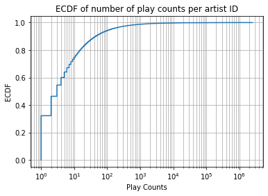

```python
pdf1 = pd.DataFrame(data=artistPopularity)
Y1=np.sort( pdf1[1] )
yvals1=np.arange(len(Y1))/float(len(Y1))
print(np.arange(len(Y1)))
plt.semilogx( Y1, yvals1 )
plt.xlabel('Play Counts')
plt.ylabel('ECDF')
plt.grid(True,which="both",ls="-")
plt.title('ECDF of number of play counts per artist ID')
plt.show()
```

**Statistical measurements**

```python
print ('Sum =', Y1.sum())
print ('Mean =', Y1.mean())
print ('Min =', Y1.min())
print ('Max =', Y1.max())
print ('Top 5 play counts:', Y1[len(Y1)-5:len(Y1)])
print ('Sum top 5 artist play counts:', Y1[len(Y1)-5:len(Y1)].sum())
print ('Percentage of top 5 artist play counts:', Y1[len(Y1)-5:len(Y1)].sum()/Y1.sum())
print ('P(playCount<=10) =', len(Y1[Y1<=10])/len(Y1))
print ('P(playCount<=1000) =', len(Y1[Y1<=1000])/len(Y1))
```

```
Sum = 371638969
Mean = 227.85566464830768
Min = 1
Max = 2502130
Top 5 play counts: [1425942 1542806 1930592 2259185 2502130]
Sum top 5 artist play counts: 9660655
Percentage of top 5 artist play counts: 0.025994730923925256
P(playCount<=10) = 0.7486793605014751
P(playCount<=1000) = 0.987435531456235
```

**Plot a bar chart to show top 5 artists In terms of absolute play counts.**

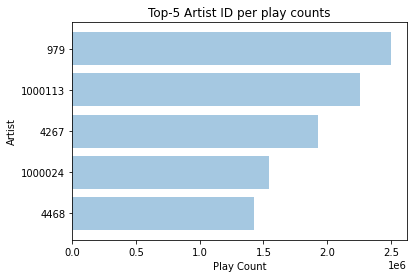

```python
sortedArtist = sorted(artistPopularity, key = lambda x: -x[1])[:5]

artistID = [w[0] for w in sortedArtist]

y_pos = range(len(sortedArtist))
frequency = [w[1] for w in sortedArtist]

plt.barh(y_pos, frequency[::-1], align='center', alpha=0.4)
plt.yticks(y_pos, artistID[::-1])
plt.xlabel('Play Count')
plt.ylabel('Artist')
plt.title('Top-5 Artist ID per play counts')
plt.show()
```

## **ANAYLSIS ON ARTIST_DATA.TXT**

```python
base="/content/dataset/artist_data.txt"
```

```python
customSchemaArtist = StructType([ \
    StructField("artistID", LongType(), True), \
    StructField("name", StringType(), True)])

artistDF = sqlContext.read \
    .format('com.databricks.spark.csv') \
    .options(header='false', delimiter='\t', mode='DROPMALFORMED') \
    .load(base , schema = customSchemaArtist) \
    .cache()
artistDF.show(5)
```

```
+--------+--------------------+
|artistID|                name|
+--------+--------------------+
| 1134999|        06Crazy Life|
| 6821360|        Pang Nakarin|
|10113088|Terfel, Bartoli- ...|
|10151459| The Flaming Sidebur|
| 6826647|   Bodenstandig 3000|
+--------+--------------------+
only showing top 5 rows
```

**Look at top 20 artists whose name contains "Aerosmith". Take a look at artists that have ID equal to 1000010 and 2082323. Are they pointing to the same artist?get artists whose name contains "Aerosmith"**

```python
artistDF[locate("Aerosmith", artistDF.name) > 0].show(20, False)
artistDF[artistDF.artistID==1000010].show()
artistDF[artistDF.artistID==2082323].show()
```

```
+--------+----------------------------------------------+
|artistID|name                                          |
+--------+----------------------------------------------+
|10586006|Dusty Springfield/Aerosmith                   |
|6946007 |Aerosmith/RunDMC                              |
|10475683|Aerosmith: Just Push Play                     |
|1083031 |Aerosmith/ G n R                              |
|6872848 |Britney, Nsync, Nelly, Aerosmith,Mary J Blige.|
|10586963|Green Day - Oasis - Eminem - Aerosmith        |
|10028830|The Aerosmith Antology2                       |
|10300357|Run-DMC + Aerosmith                           |
|2027746 |Aerosmith by MusicInter.com                   |
|1140418 |[rap]Run DMC and Aerosmith                    |
|10237208|Aerosmith + Run DMC                           |
|10588537|Aerosmith, Kid Rock, & Run DMC                |
|9934757 |Aerosmith - Big Ones                          |
|10437510|Green Day ft. Oasis & Aerosmith               |
|6936680 |RUN DNC & Aerosmith                           |
|10479781|Aerosmith Hits                                |
|10114147|Charlies Angels - Aerosmith                   |
|1262439 |Kid Rock, Run DMC & Aerosmith                 |
|7032554 |Aerosmith & Run-D.M.C.                        |
|10033592|Aerosmith?                                    |
+--------+----------------------------------------------+
only showing top 20 rows

+--------+---------+
|artistID|     name|
+--------+---------+
| 1000010|Aerosmith|
+--------+---------+

+--------+------------+
|artistID|        name|
+--------+------------+
| 2082323|01 Aerosmith|
+--------+------------+
```

They maybe pointing to the same artist. To find this out we will also be using alias_data.txt which contains the ids of mispelled artists and standard artists.

## **ANALYSIS ON ARTIST_ALIAS.TXT**

```python
base="/content/dataset/artist_alias.txt"
```

```python
customSchemaArtistAlias = StructType([ \
    StructField("mispelledID", LongType(), True), \
    StructField("standardID", LongType(), True)])

artistAliasDF = sqlContext.read \
    .format('com.databricks.spark.csv') \
    .options(header='false', delimiter='\t', mode='DROPMALFORMED') \
    .load(base , schema = customSchemaArtistAlias) \
    .cache()

artistAliasDF.show(5)
```

```
+-----------+----------+
|mispelledID|standardID|
+-----------+----------+
|    1092764|   1000311|
|    1095122|   1000557|
|    6708070|   1007267|
|   10088054|   1042317|
|    1195917|   1042317|
+-----------+----------+
only showing top 5 rows
```

**Verify the answer of "Are artists that have ID equal to 1000010 and 2082323 the same ?" by finding the standard ids corresponding to the mispelled ids 1000010 and 2082323 respectively.**

```python
artistAliasDF[artistAliasDF.mispelledID == "1000010" ].show()
artistAliasDF[artistAliasDF.mispelledID == "2082323" ].show()
```

```
+-----------+----------+
|mispelledID|standardID|
+-----------+----------+
+-----------+----------+

+-----------+----------+
|mispelledID|standardID|
+-----------+----------+
|    2082323|   1000010|
+-----------+----------+
```

After evaluating mispelledID, we have found that they both are same artist because the artistID = "2082323" has standardID="1000010", which means representing the same artist

**Construct a dictionary that maps each non-standard id to its standard id.**

```python
artistAlias = artistAliasDF.rdd.map(lambda row: (row.mispelledID,row.standardID)).collectAsMap()
len(artistAlias)
```

```
190893
```

The total number row of the dictionary now 190893 artists. We should standalize the field of the data which more likely to create ambiguity

**Using funtion map on Spark Dataframe will give us an RDD. We can convert this RDD back to Dataframe by using sqlContext.createDataFrame(rdd_name, sql_schema)**

```python
from time import time

bArtistAlias = sc.broadcast(artistAlias)

def replaceMispelledIDs(fields):
    finalID = bArtistAlias.value.get(fields[1] ,fields[1])
    return (fields[0], finalID, fields[2])

t0 = time()

newUserArtistDF = sqlContext.createDataFrame(
    userArtistDF.rdd.map(replaceMispelledIDs),
    userArtistDataSchema
)
newUserArtistDF.show(5)
t1 = time()

print('The script takes %f seconds' %(t1-t0))
newUserArtistDF = newUserArtistDF.cache()
```

```
+-------+--------+---------+
| userID|artistID|playCount|
+-------+--------+---------+
|1000002|       1|       55|
|1000002| 1000006|       33|
|1000002| 1000007|        8|
|1000002| 1000009|      144|
|1000002| 1000010|      314|
+-------+--------+---------+
only showing top 5 rows

The script takes 0.638038 seconds
```

**How many unique artists? Compare with the result when using old data.**

```python
uniqueArtists = newUserArtistDF.select('artistID').distinct().count()
print("Total n. of artists: ", uniqueArtists)
```

```
Total n. of artists:  1568126
```

The number of artists is reduced (from 1631028 to 1568126) after cleaning and standardization (replacing mispelledID with standardID).

**calculate top-10 artists in term of play counts and plotting them**

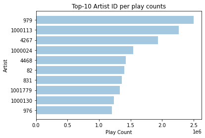

[figure not shown]

```python
top10ArtistsPC = newUserArtistDF.groupBy('artistID').sum('playCount').orderBy('sum(playCount)', ascending=0).take(10)
y_pos = list(range(len(top10ArtistsPC)))
pdf = pd.DataFrame(data=top10ArtistsPC)
plt.barh(y_pos, pdf[1][::-1], align='center', alpha=0.4)
plt.yticks(y_pos, pdf[0][::-1])
plt.xlabel('Play Count')
plt.ylabel('Artist')
plt.title('Top-10 Artist ID per play counts')
plt.show()
```

After removing all mispelledID, there is little increase in playCounts of top-10-artists.

The chart shows that playCount dramatiaclly decreases from the 1st artist to the 4th artist in top-10-artists, but from the 4th artist to 10th artist, it decreases slightly.

**Calculate top 10 users in term of play counts**

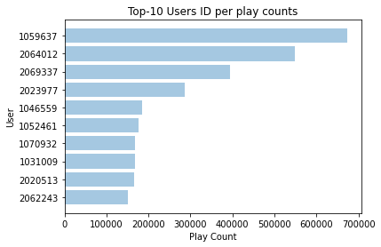

```python
top10UsersByPlayCount = newUserArtistDF.groupBy("userID").sum('playCount').orderBy('sum(playCount)', ascending=0).take(10)

y_pos = list(range(len(top10UsersByPlayCount)))
pdf = pd.DataFrame(data=top10UsersByPlayCount)

plt.barh(y_pos, pdf[1][::-1], align='center', alpha=0.4)
plt.yticks(y_pos, pdf[0][::-1])
plt.xlabel('Play Count')
plt.ylabel('User')
plt.title('Top-10 Users ID per play counts')
plt.show()
```

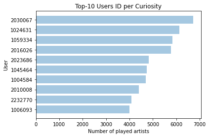

```python
top10UsersByCuriosity = (newUserArtistDF.dropDuplicates(['userID', 'artistID'])
                             .groupBy("userID")
                             .count()
                             .orderBy('count', ascending=0)
                             .take(10)
                         )

#print(top10UsersByCuriosity)
y_pos = range(len(top10UsersByCuriosity))

pdf = pd.DataFrame(data=top10UsersByCuriosity)

plt.barh(y_pos, pdf[1][::-1], align='center', alpha=0.4)
plt.yticks(y_pos, pdf[0][::-1])
plt.xlabel('Number of played artists')
plt.ylabel('User')
plt.title('Top-10 Users ID per Curiosity')
plt.show()
```

## **Music Recommender System using ALS Algorithm with Apache Spark and Python**

According to the properties of data, we need to choose a recommender algorithm that is suitable for this implicit feedback data. It means that the algorithm should learn without access to user or artist attributes such as age, genre. Therefore, an algorithm of type collaborative filtering is the best choice.

**IMPORT IMPORTANT LIBRARIES**

```python
import findspark
findspark.init()

from pyspark.mllib.recommendation import *
import random
from operator import *
from collections import defaultdict
from pyspark import SparkContext
from pyspark.sql import SQLContext
from pyspark.sql.types import *
from pyspark.sql import Row
from pyspark.sql.functions import *

%matplotlib inline
import matplotlib.pyplot as plt
import pandas as pd
import numpy as np
from time import time
```

**INITIALIZE THE SPARK CONTEXT**

```python
from pyspark import SparkContext, SparkConf
spark = SparkContext.getOrCreate()
spark.stop()
spark = SparkContext('local','Recommender')
```

**Import test files from location into RDD variables**

```python
artistData = spark.textFile('/content/drive/MyDrive/artist_data_small.txt').map(lambda s:(int(s.split("\t")[0]),s.split("\t")[1]))
artistAlias = spark.textFile('/content/drive/MyDrive/artist_alias_small.txt')
userArtistData = spark.textFile('/content/drive/MyDrive/user_artist_data_small.txt')
```

**Split a sequence into seperate entities and store as int**

```python
userArtistData = userArtistData.map(lambda s:(int(s.split(" ")[0]),int(s.split(" ")[1]),int(s.split(" ")[2])))
```

**Create a dictionary of the 'artistAlias' dataset**

```python
artistAliasDictionary = {}
dataValue = artistAlias.map(lambda s:(int(s.split("\t")[0]),int(s.split("\t")[1])))
for temp in dataValue.collect():
    artistAliasDictionary[temp[0]] = temp[1]
```

**If artistid exists, replace with artistsid from artistAlias, else retain original**

```python
userArtistData = userArtistData.map(lambda x: (x[0], artistAliasDictionary[x[1]] if x[1] in artistAliasDictionary else x[1], x[2]))
```

**Create an RDD consisting of 'userid' and 'playcount' objects of original tuple**

```python
userSum = userArtistData.map(lambda x:(x[0],x[2]))
playCount1 = userSum.map(lambda x: (x[0],x[1])).reduceByKey(lambda a,b : a+b)
playCount2 = userSum.map(lambda x: (x[0],1)).reduceByKey(lambda a,b:a+b)
playSumAndCount = playCount1.leftOuterJoin(playCount2)
```

```python
playSumAndCount = playSumAndCount.map(lambda x: (x[0],x[1][0],int(x[1][0]/x[1][1])))
```

**Compute and display users with the highest playcount along with their mean playcount across artists**

```python
TopThree = playSumAndCount.top(3,key=lambda x: x[1])
for i in TopThree:
    print('User '+str(i[0])+' has a total play count of '+str(i[1])+' and a mean play count of '+str(i[2])+'.')
```

```
User 1059637 has a total play count of 674412 and a mean play count of 1878.
User 2064012 has a total play count of 548427 and a mean play count of 9455.
User 2069337 has a total play count of 393515 and a mean play count of 1519.
```

**Split the 'userArtistData' dataset into training, validation and test datasets.**

Split the dataset into 3 parts, trainingData, validationData and testData in the ratio of 4:4:2

Since these dataset would be used repeatedly, we might want to cache this to avoid re-computation of the same RDDs.

```python
trainData, validationData, testData = userArtistData.randomSplit((0.4,0.4,0.2),seed=13)
trainData.cache()
validationData.cache()
testData.cache()
```

```
PythonRDD[21] at RDD at PythonRDD.scala:53
```

**Display the first 3 records of each dataset followed by the total count of records for each datasets**

```python
print(trainData.take(3))
print(validationData.take(3))
print(testData.take(3))
print(trainData.count())
print(validationData.count())
print(testData.count())
```

```
[(1059637, 1000049, 1), (1059637, 1000056, 1), (1059637, 1000114, 2)]
[(1059637, 1000010, 238), (1059637, 1000062, 11), (1059637, 1000123, 2)]
[(1059637, 1000094, 1), (1059637, 1000112, 423), (1059637, 1000113, 5)]
19761
19862
9858
```

**BUILDING A MODEL**

```python
def modelEval(model, dataset):

    # All artists in the 'userArtistData' dataset
    AllArtists = spark.parallelize(set(userArtistData.map(lambda x:x[1]).collect()))
    # Set of all users in the Validation/Testing dataset

    AllUsers = spark.parallelize(set(dataset.map(lambda x:x[0]).collect()))


    # Create a dictionary of (key, values) for Validation/Testing dataset

    ValidationAndTestingDictionary ={}
    for temp in AllUsers.collect():
        tempFilter = dataset.filter(lambda x:x[0] == temp).collect()
        for item in tempFilter:
            if temp in ValidationAndTestingDictionary:
                ValidationAndTestingDictionary[temp].append(item[1])
            else:
                ValidationAndTestingDictionary[temp] = [item[1]]


    # Create a dictionary of (key, values) for training dataset

    TrainingDictionary = {}
    for temp in AllUsers.collect():
        tempFilter = trainData.filter(lambda x:x[0] == temp).collect()
        for item in tempFilter:
            if temp in TrainingDictionary:
                TrainingDictionary[temp].append(item[1])
            else:
                TrainingDictionary[temp] = [item[1]]


    # Calculate the prediction score for each user

    PredictionScore = 0.00
    for temp in AllUsers.collect():
        ArtistPrediction =  AllArtists.map(lambda x:(temp,x))
        ModelPrediction = model.predictAll(ArtistPrediction)
        tempFilter = ModelPrediction.filter(lambda x :not x[1] in TrainingDictionary[x[0]])
        topPredictions = tempFilter.top(len(ValidationAndTestingDictionary[temp]),key=lambda x:x[2])
        l=[]
        for i in topPredictions:
            l.append(i[1])
        PredictionScore+=len(set(l).intersection(ValidationAndTestingDictionary[temp]))/len(ValidationAndTestingDictionary[temp])


    # Print average score of the model for all users for the specified rank

    print("The model score for rank "+str(model.rank)+" is ~"+str(PredictionScore/len(ValidationAndTestingDictionary)))
```

**MODEL SCORE**  
Here we evaluate our model on the validation dataset based on different rank parameters. The rank parameter corresponds to the number of latent factors in the matrix factorization of the ALS algorithm. Hence we run the model for different rank parameter and then we choose the one which yielded the best accuracy.

```python
rankList = [2,10,20]
for rank in rankList:
     model = ALS.trainImplicit(trainData, rank , seed=345)
     modelEval(model,validationData)
```

```
The model score for rank 2 is ~0.07535599799693796
The model score for rank 10 is ~0.09765418032407164
The model score for rank 20 is ~0.08667584027612182
```

**We choose the model which yielded the highest accuracy as our final model to make recommendations.**

```python
bestModel = ALS.trainImplicit(trainData, rank=10, seed=345)
modelEval(bestModel, testData)
```

```
The model score for rank 10 is ~0.06445912100969664
```

### **Find the top 5 artists for a particular user and list their names**

Our model is ready to make recommendations. We now make top 5 artist recommendations for user 1059637. The function recommendProducts takes userId as the first input parameter and an integer n, while returning the top n highest ranked recommendations.

```python
TopFive = bestModel.recommendProducts(1059637,5)
for item in range(0,5):
    print("Artist "+str(item)+": "+artistData.filter(lambda x:x[0] == TopFive[item][1]).collect()[0][1])
```

```
Artist 0: Something Corporate
Artist 1: My Chemical Romance
Artist 2: Rage Against the Machine
Artist 3: blink-182
Artist 4: Evanescence
```

[figure not shown]